# Linear regression workshop for HGSS

Alex Diaz-Papkovich

December 3, 2019

## What is linear regression?

Regression is a set of methods to measure and estimate the relationship between variables. The idea is your data will “regress” to some function. The focus of this workshop is linear regression, one of the most effective and widely-used statistical tools. We’ll begin with simple types of data and relationships and work our way up to models with interactions.

### Why linear regression?

Because it’s:

- interpretable
- easy to implement
- got good statistical properties
- robust

### Formulation

There are a few basic assumptions that you must make when doing linear regression.

The first assumption is that your data are related by a *linear relationship*, that is, it can be expressed as a linear equation. In the simplest case, we take the equation of a line, $y=mx + b$, where we know what the $y$ and $x$ values are and estimate the values of the slope $m$ and intercept $b$. For easier notation, we typically denote the intercept as $\beta_0$ and the slope as $\beta_1$ and rearrange the equation as:
$$y=\beta_{0} + \beta_{1}x$$

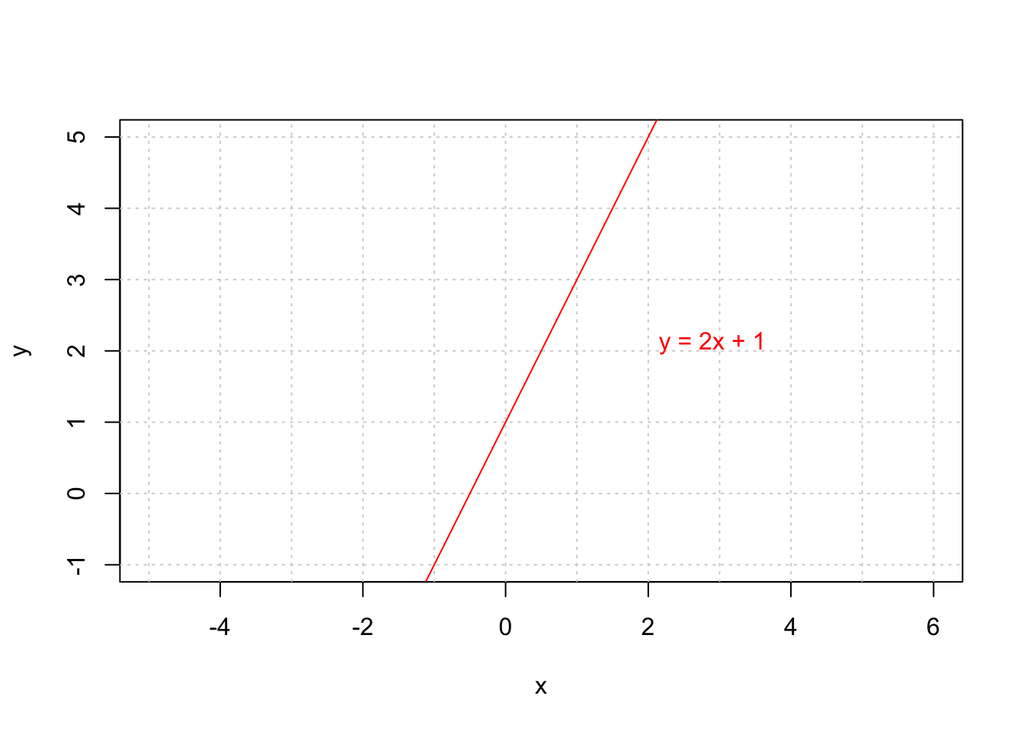

We will (hopefully!) have more than one value for each $(x,y)$ pair, so we denote each observation $(x_i,y_i)$. If we have $N$ samples, then $i$ takes the values $1 \dots N$, so our data are described as the collection of observations $(x_1,y_1)\dots(x_N,y_N)$. Given this set of data, our model is now:
$$y_i = \beta_{0} + \beta_{1}x_{i} \text{ , for } i = 1 \dots N$$

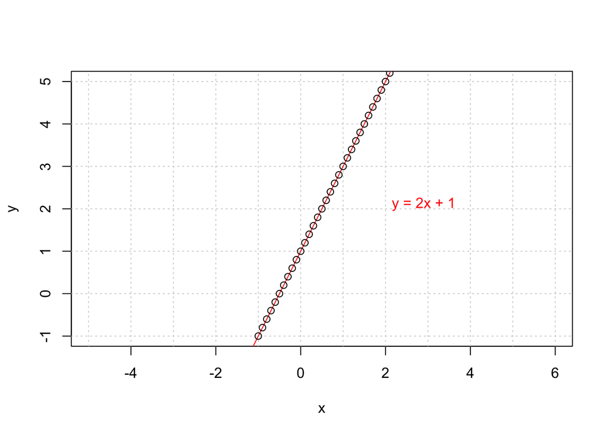

Finally, we need to add noise to our model. Our observations will never be perfect, so we have to build this error into the model. The errors are denoted by $\epsilon_{i}$, and we assume that they independently follow the same Normal distribution centred around $0$ and with a constant variance, $\sigma^{2}$. This is written as $\epsilon_{i} \stackrel{iid}{\sim}N(0,\sigma^{2})$. Now, our model looks like:
$$y_i = \beta_{0} + \beta_{1}x_{i} + \epsilon_{i} \text{ , for } i = 1 \dots N \text{ , } \epsilon_{i} \stackrel{iid}{\sim}N(0,\sigma^{2})$$

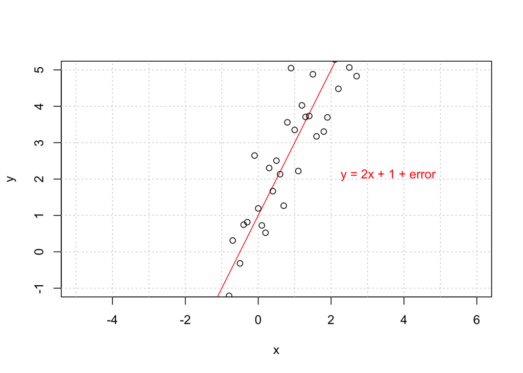

There are several assumptions with this approach:

- The errors are *random*
- The errors are *independent* ($\implies$ uncorrelated)
- The errors are *normally distributed*
- The errors have *mean zero*
- The errors have *the same variance* (homoscedasticity)

#### How do we estimate $\beta$?

Here we started with a linear equation and generated our data. In real life, we have our data and need to estimate the linear equation. Given our observations $(x_i,y_i)$, we want to estimate $\beta_0$ and $\beta_1$, denoted as $\hat{\beta_j}$ for $j=0,1$. The value of $\hat\beta_1$ is the estimate of the unit-change between $x_i$ and $y_i$. For example, if our $y$ values are a person’s weight (in kg) and our $x$ values are height (in cm), then $\hat{\beta_1}$ is the estimate of how much somebody’s weight in kg increases for a 1cm change in height.

One logical approach to estimate the values of the $\beta$s is in a way that would make the errors, or equivalently sum of their squares, as small as possible. This is the **ordinary least squares** estimator.

$$y_i = \beta_{0} + \beta_{1}x_{i} + \epsilon_{i}
\\ \text{rearranged as: } \epsilon_i = y_i - \beta_{0} - \beta_{1}x_{i}$$
If we have $N$ observations, then the sum of the squared errors is
$$\sum_{i}^{N}\epsilon_{i}^{2} = \sum_{i}^{N}(y_{i} - \beta_{0} - \beta_{1}x_{i})^{2} = SSE$$

Geometrically, we are drawing squares on our regression plot: for each observation $i$, the square has sides of length $\epsilon_i$ (the distance between the point and the regression line) and area $\epsilon_i^2$. The goal of the least squares estimator is to make the sum of the areas of these squares as small as possible. For an intuitive animation, [see this web page](http://setosa.io/ev/ordinary-least-squares-regression/).

Using some calculus, the estimates of the $\beta$s turn out to be:

$$\hat{\beta_1} = \frac{\sum^{N}_{i=1}(x_{i} - \bar{x})(y_{i} - \bar{y})}
{\sum_{i=1}^{N}(x_{i} - \bar{x})^{2}} = \frac{SS_{xy}}{SS_{xx}}$$

$$\hat{\beta_0} = \bar{y} - \hat{\beta_{1}}\bar{x}$$

Because of the assumptions we made earlier, our estimators have some very nice statistical properties. If our errors are uncorrelated and have mean zero and are homoscedasticity, then our estimates are the best linear unbiased estimator. Being unbiased means that the estimator of $\beta$, on average, the true value of the $\beta$. Being the “best” estimator means it has the lowest variance of all linear unbiased estimators. There are numerous websites and textbooks that discuss derivations of estimates in great detail.

### Notation and terminology

Models are usually written in matrix notation for convenience. So far we have worked with one continuous $y$ variable and one continuous $x$ variable. This is called **simple linear regression**. The matrix formulation of simple linear regression is:

$$Y = \begin{pmatrix}
y_1 \\ y_2 \\ \dots \\ y_N
\end{pmatrix}, X =
\begin{pmatrix}
1 & x_{1} \\ 1 & x_{2} \\ \dots & \dots \\ 1 & x_{N}
\end{pmatrix},
\beta = \begin{pmatrix}
\beta_{0} \\ \beta_{1}
\end{pmatrix},
\epsilon = \begin{pmatrix}
\epsilon_{1} \\ \epsilon_{2} \\ \dots \\ \epsilon_{N}
\end{pmatrix}$$
$$Y = \beta X + \epsilon, \epsilon_{i} \stackrel{iid}{\sim}N(0,\sigma^{2})$$

There are many terms used to describe the variables and types of models used. This is a brief reference.

- Independent variable, regressor, feature, explanatory variable, etc: These are all terms for your $x$ variables.
- Dependent variable, regressand, target, outcome, response, etc: These are all terms for your $y$ variable, which you are modeling using your $x$ variables
- Simple/single linear regression: The simplest regression model, $y_i = \beta_0 + x_i \beta_1 + \epsilon_i$
- Multiple linear regression: Linear regression with multiple independent variables, $y_i = \beta_0 + x_{i,1}\beta_{1} + x_{i,2}\beta_{2} + \dots + x_{i,p}\beta_{p} + \epsilon_i$.
- Multivariate linear regression: Linear regression with multiple dependent (response) variables that share a covariance structure, $Y_{ij} = \beta_{0j} + \beta_{1j}X_{i1} + \dots + \beta_{pj}X_{ip} + \epsilon_{ij}$ for observations $i=1, \dots, N$ and dependent variables $j = 1, \dots,m$. We won’t go into this in this workshop, but it’s useful for when you want to simultaneously model related outcomes, such as multiple phenotypes given a shared input, like gene expression levels.

As an aside, this is why it’s important to know, mathematically, what your model looks like. Using ambiguous terms makes it tedious to understand and/or replicate research and results.

## Linear regression in R

### Simple linear regression

Most scientific programming languages have built-in linear regression. In R, linear models are constructed with the `lm` function. The general format is:

`my_model <- lm(y ~ x1 + x2 + ... xp, data = my_data)`

As an example, let’s generate some data and run a regression on it.

```r
set.seed(20191203) # set a seed for reproducibility

# lets set up some true data
b0 <- -300 # true beta_0
b1 <- 7 # true beta_1
N <- 40 # sample size

# generate some x values, let's pretend it's height in inches
# a sample of size N bounded between 50 and 80
x_data <- runif(N,50,80)

# generate some random normal errors
errs <- rnorm(N, mean = 0, sd = 30)

y_data <- b0 + x_data*b1 + errs
```

The first thing you should do is **look at your data**. This should give you some idea of whether your data are linearly related.

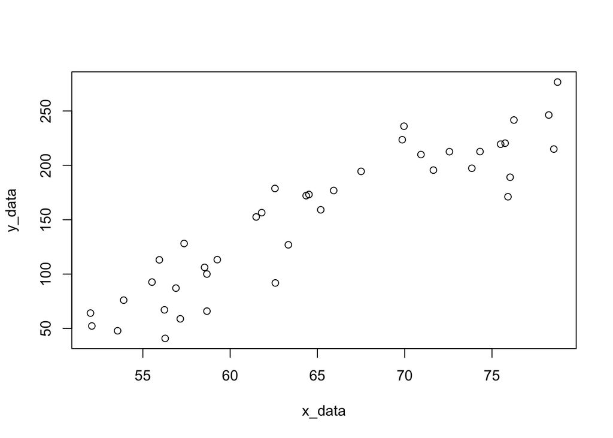

```r
plot(x_data, y_data)
```

Note that the data is still kind of noisy – this is fine, as data is not always clearly linearly related. However, if you saw other shapes (like parabolas, exponential growth, or periodicity), then the linear model would need some changes. Moving on, we code our model as:

```r
my_model <- lm(y_data ~ x_data)
```

To look at the results of our model, we use the `summary` function.

```r
summary(my_model)
```

```
##
## Call:
## lm(formula = y_data ~ x_data)
##
## Residuals:
##     Min      1Q  Median      3Q     Max
## -58.154 -13.992   1.414  24.988  49.085
##
## Coefficients:
##              Estimate Std. Error t value Pr(>|t|)
## (Intercept) -310.4223    33.3369  -9.312 2.38e-11 ***
## x_data         7.1091     0.5088  13.972  < 2e-16 ***
## ---
## Signif. codes:  0 '***' 0.001 '**' 0.01 '*' 0.05 '.' 0.1 ' ' 1
##
## Residual standard error: 26.89 on 38 degrees of freedom
## Multiple R-squared:  0.8371, Adjusted R-squared:  0.8328
## F-statistic: 195.2 on 1 and 38 DF,  p-value: < 2.2e-16
```

What’s going on in this output?

```
Call:
lm(formula = y_data ~ x_data)
```

The first part shows the formula R used to run the analysis.

```
Residuals:
    Min      1Q  Median      3Q     Max
-58.154 -13.992   1.414  24.988  49.085
```

This portion is a summary of the residuals (errors). We’ll follow up later.

```
Coefficients:
             Estimate Std. Error t value Pr(>|t|)
(Intercept) -310.4223    33.3369  -9.312 2.38e-11 ***
x_data         7.1091     0.5088  13.972  < 2e-16 ***
---
Signif. codes:  0 ‘***’ 0.001 ‘**’ 0.01 ‘*’ 0.05 ‘.’ 0.1 ‘ ’ 1
```

The coefficients are the meat of the analysis. They are our slopes and intercept. The estimate for our intercept is $\hat{\beta_{0}} = -310.4223$ and for the slope is $\hat{\beta_1} = 7.1091$. Recall our original values when generating the data were $-300$ and $7$, respectively, so this is pretty good!

The standard error refers to the standard error for the estimate of particular $\beta$ value. In this case, the standard error around the slope is $0.5088$, and the standard error around the intercept is $33.3369$. Next we have the t-statistic and p-value for each $\beta$. Note that the t-statistic is the estimate divided by the standard error, and the p-value is the probability that the t-statistic is drawn at random from a student’s t-distribution with $N-p-1$ degrees of freedom, where $p$ is the number of independent variables. In principle you could calculate these values yourself… but that’s what software is for.

Moving on, although we have estimates of our $\beta$ values, we’d also like to know how likely it is that it’s actually zero (perhaps the standard deviations are so large that $\beta$ could plausibly be $0$). So for each slope, using the aforementioned t-statistic, we are testing:

$$H_{0}: \beta_{i} = 0 \text{ vs. } H_{A}: \beta_i \ne 0$$

In this case our p-value falls below $0.05$ for both $\beta_0$ and $\beta_1$, so we reject the null hypothesis in each case. That is, our slopes are non-zero. If you run an analysis with multiple $\beta$s, you will need to asses the significance of each slope and remove those that do not appear to be significant.

```
Residual standard error: 26.89 on 38 degrees of freedom
Multiple R-squared:  0.8371,    Adjusted R-squared:  0.8328
F-statistic: 195.2 on 1 and 38 DF,  p-value: < 2.2e-16
```

The residual standard error is the average amount that the predicted variable will deviate from the fitted line. So on average, our $y$ values will be about $26.89$ away from the line.

The multiple $R^2$ is the squared Pearson correlation coefficient, and the adjusted $R^2$ is a version that adjusts for the number of parameters. It is usually bounded between $0$ and $1$, and is the proportion of variance explained by your model – the closer your model is to $1$, the better of a fit your model is. However, adding more and more variables just to get a better $R^2$ value is discouraged as it leads to model overfitting. Remember, the goal is to explain relationships your data, and not to meet some arbitrary threshold!

The F-statistic tests the hypothesis that *all* of your non-intercept $\beta$ values are $0$, ie:
$$H_0: \beta_1 = \dots = \beta_p = 0 \text{ vs. } H_A:\text{At least one slope is not zero}$$
If your F-statistic is non-significant, your model has serious issues as none of your predictors are useful! In this case it’s a moot point as we only have one slope anyway.

We can visualize what the model looks like:

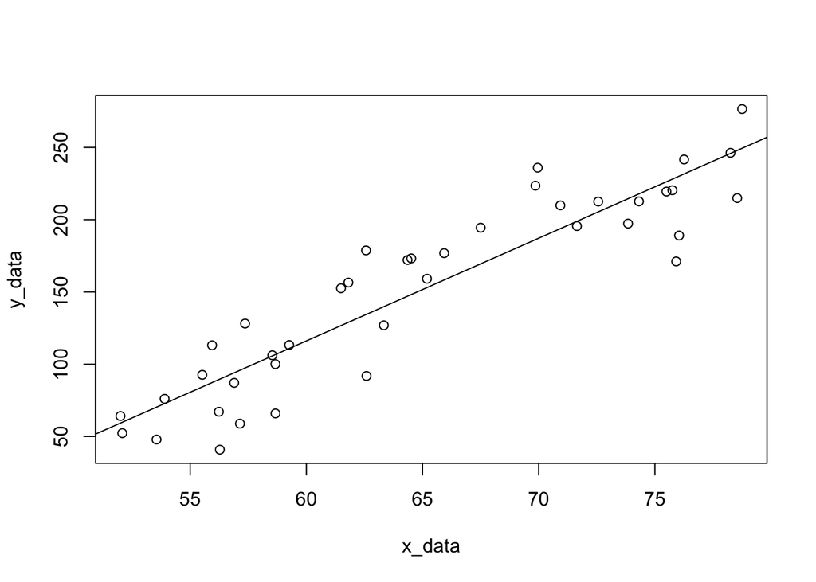

```r
plot(x_data, y_data)
abline(my_model)
```

### Multiple variables

Often we want to test multiple variables. Luckily, this is straightforward to do – we simply add more variables to our model and carry out the rest of the tests as intended. Mathematically, we have:
$$y_i = \beta_0 + \beta_1x_{i1} + \beta_{2}x_{i2} + \epsilon_{i}$$

```r
set.seed(20191203) # set a seed for reproducibility

# lets set up some true data
b0 <- -300 # true beta_0
b1 <- 7 # true beta_1
b2 <- -12 # true beta_2
N <- 40 # sample size

# generate some x values again
x1_data <- runif(N,50,80)
x2_data <- runif(N,10,20)

# generate some random normal errors
errs <- rnorm(N, mean = 0, sd = 30)

y_data <- b0 + x1_data*b1 + x2_data*b2 + errs
```

In this case, we’ve created our $y$ variable as a linear combination of two variables ($x1$ and $x2$). Lets code this in R and see what the results are. To begin, we’ll put our data into a dataframe – so far we’ve only worked with vectors. Generally you’ll be working with dataframes (or some equivalent if you’re working in another language), which are easier to manage. The results will be the same, but slightly easier to follow

```r
# put the data into a dataframe

my_data <- data.frame(y_data, x1_data, x2_data) # put the data into a frame
colnames(my_data) <- c("y","x1","x2") # give names to our variables

my_model_2 <- lm(y ~ x1 + x2, data = my_data) # set up the model
summary(my_model_2) # output the analysis
```

```
##
## Call:
## lm(formula = y ~ x1 + x2, data = my_data)
##
## Residuals:
##     Min      1Q  Median      3Q     Max
## -56.478 -16.155   0.116  14.658  54.134
##
## Coefficients:
##              Estimate Std. Error t value Pr(>|t|)
## (Intercept) -253.3287    40.1480  -6.310 2.39e-07 ***
## x1             6.0382     0.5001  12.075 2.12e-14 ***
## x2           -11.0692     1.4557  -7.604 4.52e-09 ***
## ---
## Signif. codes:  0 '***' 0.001 '**' 0.01 '*' 0.05 '.' 0.1 ' ' 1
##
## Residual standard error: 26.42 on 37 degrees of freedom
## Multiple R-squared:  0.849,  Adjusted R-squared:  0.8408
## F-statistic:   104 on 2 and 37 DF,  p-value: 6.471e-16
```

The estimates are:

- $\hat{\beta_0} = -253.3287$ ($\beta_0 = -300$)
- $\hat{\beta_{1}} = 6.0382$ ($\beta_1 = 7$)
- $\hat{\beta_{2}} = -11.0692$ ($\beta_2 = -12$)

The results are close. As an exercise, let’s see what happens if we raise the sample size to something huge, say, $10,000$.

```r
set.seed(20191203) # set a seed for reproducibility

# lets set up some true data
b0 <- -300 # true beta_0
b1 <- 7 # true beta_1
b2 <- -12 # true beta_2
N <- 10000 # sample size

# generate some x values again
x1_data <- runif(N,50,80)
x2_data <- runif(N,10,20)

# generate some random normal errors
errs <- rnorm(N, mean = 0, sd = 30)

y_data <- b0 + x1_data*b1 + x2_data*b2 + errs

my_model_3 <- lm(y_data ~ x1_data + x2_data)
summary(my_model_3)
```

```
##
## Call:
## lm(formula = y_data ~ x1_data + x2_data)
##
## Residuals:
##      Min       1Q   Median       3Q      Max
## -116.602  -19.806    0.155   19.892  112.635
##
## Coefficients:
##               Estimate Std. Error t value Pr(>|t|)
## (Intercept) -299.24504    2.72770  -109.7   <2e-16 ***
## x1_data        6.97908    0.03451   202.2   <2e-16 ***
## x2_data      -11.96075    0.10307  -116.0   <2e-16 ***
## ---
## Signif. codes:  0 '***' 0.001 '**' 0.01 '*' 0.05 '.' 0.1 ' ' 1
##
## Residual standard error: 29.84 on 9997 degrees of freedom
## Multiple R-squared:  0.8436, Adjusted R-squared:  0.8435
## F-statistic: 2.695e+04 on 2 and 9997 DF,  p-value: < 2.2e-16
```

So as the sample size gets bigger, the estimates of the $\beta$ values get much closer to the true value!

We can also visualize this regression, although since we’ve got an extra dimension, we are now fitting a plane in 3D space, as opposed to a line in 2D space.

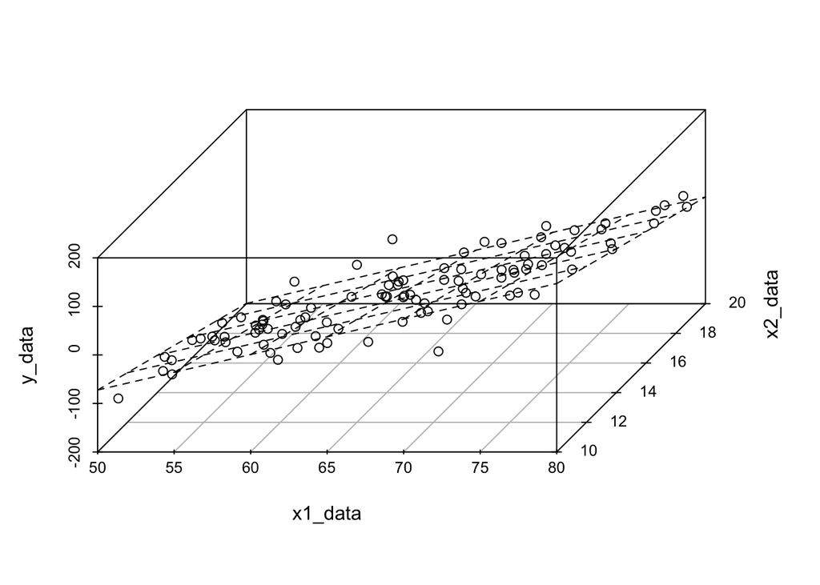

```r
set.seed(20191203) # set a seed for reproducibility

# lets set up some true data
b0 <- -300 # true beta_0
b1 <- 7 # true beta_1
b2 <- -12 # true beta_2
N <- 100 # sample size

# generate some x values again
x1_data <- runif(N,50,80)
x2_data <- runif(N,10,20)

# generate some random normal errors
errs <- rnorm(N, mean = 0, sd = 30)

y_data <- b0 + x1_data*b1 + x2_data*b2 + errs

my_model_3 <- lm(y_data ~ x1_data + x2_data)

library(scatterplot3d) # load the library for visualization - you may need to install this
plot3d <- scatterplot3d(cbind.data.frame(x1_data,x2_data,y_data), angle=55)
plot3d$plane3d(my_model_3)
```

Unfortunately we can’t perceive beyond three dimensions. But for now, this will do.

### Categorical data

Categorical data is measured through *dummy variables*. These take on binary values, {0,1}, and are mutually exclusive. Common example include sex and treatment/control. When using multiple values of a categorical value (e.g. Control, Treatment1, Treatment2, etc), you must create one dummy variable per category. In R, you can do this automatically using the `factor` function. The results of regression will be relative to some reference group. For example, if you code for sex, then the estimated $\beta$ will be the difference in averages for males relative to females, without loss of generality. Our model is:

$$y_i = \beta_0 + \beta_1x_{i} + \epsilon_{i} \text{ ,where } x_{i}=\{0,1\}$$

Lets simulate some more data again, this time from two groups.

```r
set.seed(20191203) # set a seed for reproducibility

ng <- 2 # number of groups
N <- 40 # sample size

# values of the true betas
b0 <- 10
b1 <- -5

group <- rep( c("group1", "group2"), each = N) # create the two sets of groups
errs <- rnorm(ng*N, 0, sd=10) # create the standard errors

y_data <- b0 + b1*(group=="group2") + errs # those in group 2 are multiplied by b1
my_model_cat <- lm(y_data ~ as.factor(group)) # define the linear model
summary(my_model_cat)
```

```
##
## Call:
## lm(formula = y_data ~ as.factor(group))
##
## Residuals:
##      Min       1Q   Median       3Q      Max
## -20.2230  -5.7237   0.0126   7.0784  19.6157
##
## Coefficients:
##                        Estimate Std. Error t value Pr(>|t|)
## (Intercept)              10.125      1.409   7.187 3.47e-10 ***
## as.factor(group)group2   -5.616      1.992  -2.819  0.00611 **
## ---
## Signif. codes:  0 '***' 0.001 '**' 0.01 '*' 0.05 '.' 0.1 ' ' 1
##
## Residual standard error: 8.911 on 78 degrees of freedom
## Multiple R-squared:  0.09245,    Adjusted R-squared:  0.08081
## F-statistic: 7.946 on 1 and 78 DF,  p-value: 0.006107
```

Once again, we retrieve pretty good estimates of our true $\beta$ values.

### Relationship to other statistical tests

Pausing to think for a moment… what are we testing? We assume our data comes from two distributions, and that the means between these distributions are different, i.e., their difference is not zero. We can visualize this via (for example) a boxplot:

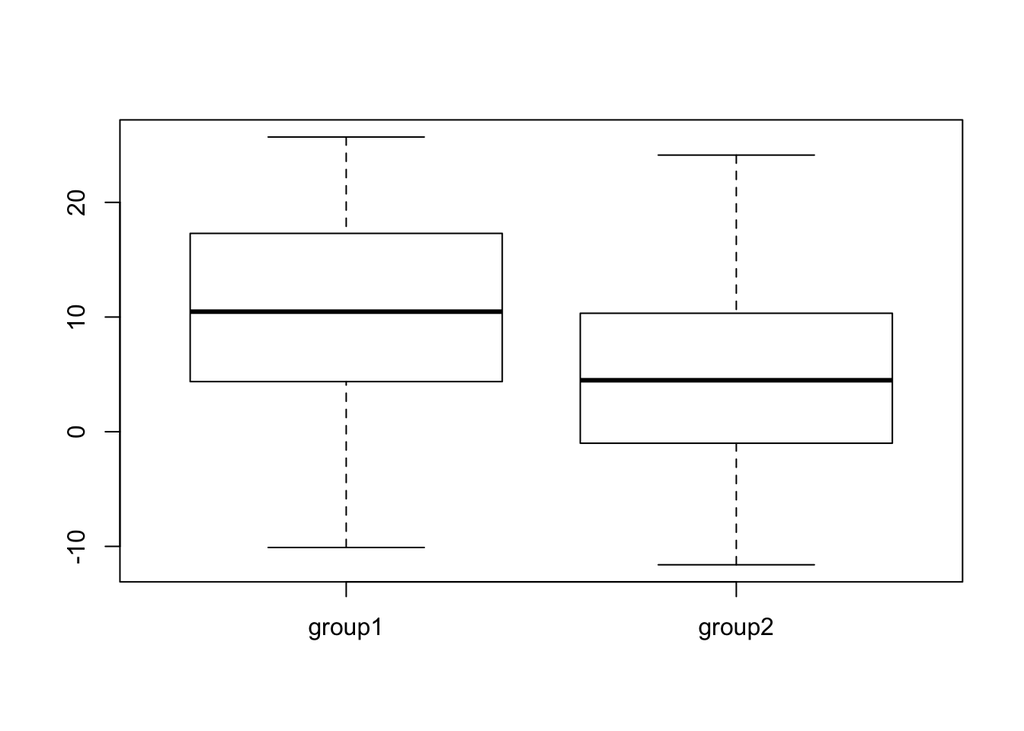

```r
plot(factor(group), y_data)
```

In fact, if we run a t-test instead of a regression model, we actually retrieve the same estimates we had before:

```r
group1_data <- y_data[1:40]
group2_data <- y_data[41:80]

t.test(group1_data, group2_data) # full t-test
```

```
##
##  Welch Two Sample t-test
##
## data:  group1_data and group2_data
## t = 2.8188, df = 77.926, p-value = 0.006108
## alternative hypothesis: true difference in means is not equal to 0
## 95 percent confidence interval:
##  1.649618 9.583172
## sample estimates:
## mean of x mean of y
## 10.125180  4.508785
```

```r
print("Estimated difference between groups:")
```

```
## [1] "Estimated difference between groups:"
```

```r
print((t.test(y_data[41:80], y_data[1:40])$estimate[1] -
  t.test(y_data[41:80], y_data[1:40])$estimate[2])) # estimated difference
```

```
## mean of x
## -5.616395
```

Basically every statistical test can be rewritten in terms of a linear model! There is an excellent intro available [here](https://lindeloev.github.io/tests-as-linear/).

### Continuous and categorical data

Using the above, we can combine categorical and continuous data into one model. We will treat $x_1$ as continuous and $x_2$ as categorical.

```r
set.seed(20191203) # set a seed for reproducibility

# lets set up some true data
b0 <- -300 # true beta_0
b1 <- 7 # true beta_1
b2 <- -30 # true beta_2
N <- 100 # sample size

# generate some x values again
x1_data <- runif(N,50,80) # generate continuous data
x2_data <- c(rep(1,N/2), rep(0,N/2)) # generate binary data

# generate some random normal errors
errs <- rnorm(N, mean = 0, sd = 30)

y_data <- b0 + x1_data*b1 + x2_data*b2 + errs

my_model_cont_cat <- lm(y_data ~ x1_data + x2_data)
summary(my_model_cont_cat)
```

```
##
## Call:
## lm(formula = y_data ~ x1_data + x2_data)
##
## Residuals:
##     Min      1Q  Median      3Q     Max
## -88.564 -16.303  -0.775  18.868  58.340
##
## Coefficients:
##              Estimate Std. Error t value Pr(>|t|)
## (Intercept) -268.5891    22.8445  -11.76  < 2e-16 ***
## x1_data        6.4711     0.3488   18.55  < 2e-16 ***
## x2_data      -28.8779     5.7635   -5.01 2.44e-06 ***
## ---
## Signif. codes:  0 '***' 0.001 '**' 0.01 '*' 0.05 '.' 0.1 ' ' 1
##
## Residual standard error: 28.68 on 97 degrees of freedom
## Multiple R-squared:  0.7851, Adjusted R-squared:  0.7807
## F-statistic: 177.2 on 2 and 97 DF,  p-value: < 2.2e-16
```

We would read this output as before. Let’s visualize what we’re looking at.

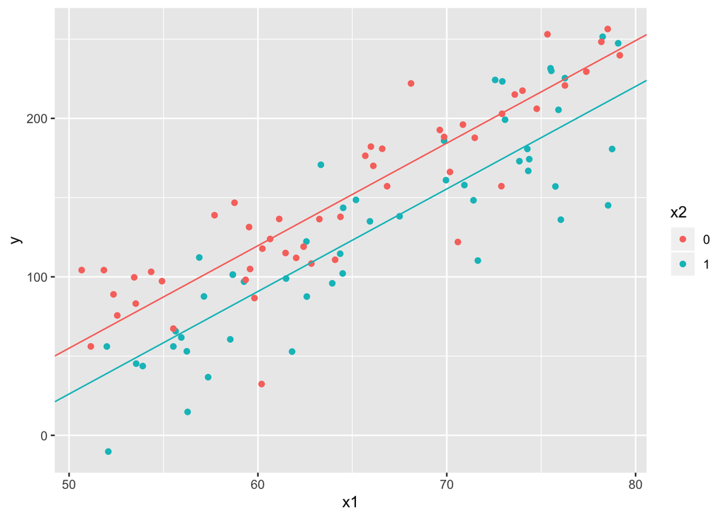

```r
library(ggplot2)# we'll use ggplot for plotting here

set.seed(20191203) # set a seed for reproducibility

# lets set up some true data
b0 <- -300 # true beta_0
b1 <- 7 # true beta_1
b2 <- -30 # true beta_2
N <- 100 # sample size

# generate some x values again
x1_data <- runif(N,50,80) # generate continuous data
x2_data <- c(rep(1,N/2), rep(0,N/2)) # generate binary data

# generate some random normal errors
errs <- rnorm(N, mean = 0, sd = 30)

y_data <- b0 + x1_data*b1 + x2_data*b2 + errs

# put together a data frame
my_data <- data.frame(y_data, x1_data, factor(x2_data))
colnames(my_data) <- c("y", "x1", "x2")

# generate a linear model
my_model_cont_cat <- lm(y ~ x1 + x2, data = my_data)

p <- ggplot(data = my_data, aes(y = y, x = x1, colour = x2)) +
  geom_point() +
  geom_abline(intercept = coef(my_model_cont_cat)[1], slope = coef(my_model_cont_cat)[2], colour="#F8766D") +
  geom_abline(intercept = coef(my_model_cont_cat)[1] + coef(my_model_cont_cat)[3],
              slope = coef(my_model_cont_cat)[2], colour = "#00BFC4")

p
```

So what we see is that depending on whether the data belongs to one category or another (sex or treatment, for example), the regression line is pushed up or down depending on the estimate of the appropriate $\beta$.

### Pitfalls

- Anscomb’s quartet
- Patterns in noise
- Simpson’s paradox

## Extensions

- LMMs, Generalized linear models, other variations of regression